# DDS_Project2-JR

JR

7/12/2021

### Introduction: DDSAnalytics is an analytics company that has decades of experience and is a leading provide of talent management services for many Fortune 100 companies. At the heart of success in companies is people and at the heart of DDSAnalytics is helping our clients succeed by not only recruiting and hiring the best talent available in the marketplace but also retaining and helping such employees flourish which in turn becomes a win-win for all. As information technology capabilities continue to grow, DDSAnalytics is planning to leverage data science in order to improve their solutions for talent management. The executive leadership has identified predicting employee turnover as its first application of data science for talent management. Before implemnting these tools accross the firm, management has tasked your data science team to conduct an analysis of existing employee data. As such, the following information details this research project.

### Link to YouTube presentation:

### https://www.youtube.com/watch?v=Y3VLaIGCA50

### Read in files

```r
Case2 = read.csv("C:/Users/Team Reed/OneDrive/JEFF/SMU/Doing Data Science/Project 2/CaseStudy2-data-JR.csv",header = TRUE)
head(Case2)
```

```
##    ID Age Attrition    BusinessTravel DailyRate      Department
## 1 254  31       Yes     Travel_Rarely       359 Human Resources
## 2 398  34       Yes     Travel_Rarely      1107 Human Resources
## 3 704  26       Yes     Travel_Rarely       920 Human Resources
## 4 716  24       Yes     Travel_Rarely       240 Human Resources
## 5 733  27       Yes Travel_Frequently      1337 Human Resources
## 6 747  29       Yes     Travel_Rarely       350 Human Resources
##   DistanceFromHome Education   EducationField EmployeeCount EmployeeNumber
## 1               18         5  Human Resources             1           1842
## 2                9         4 Technical Degree             1           1467
## 3               20         2          Medical             1           1818
## 4               22         1  Human Resources             1           1714
## 5               22         3  Human Resources             1           1944
## 6               13         3  Human Resources             1           1844
##   EnvironmentSatisfaction Gender HourlyRate JobInvolvement JobLevel
```

[output cut: 62 more lines]

### Exploratory Data Analysis

### Create graphs in order to assess relationship of Attrition with variables before researching further

### Start with bar charts and use fill in order to see breakdown of Attrition within categories

### Notable results worth researching further: JobRole, JobInvolvement, WorkLifeBalance, Job Satisfaction

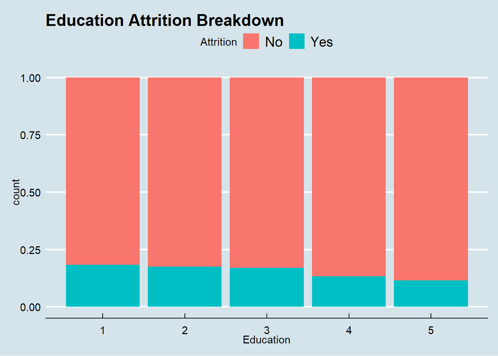

```r
library(ggplot2)
library(magrittr)
library(ggthemes)
ggplot(Case2, aes(x = Education, fill = Attrition)) + geom_bar(position = "fill") + ggtitle("Education Attrition Breakdown") + theme_economist()
```

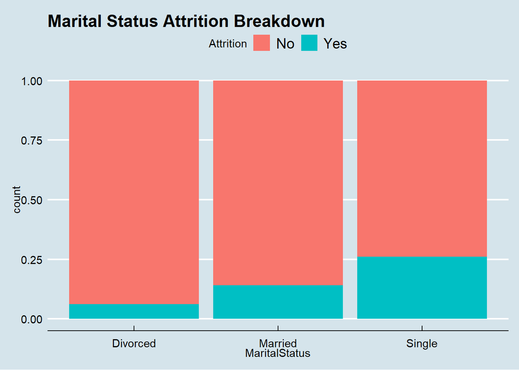

```r
ggplot(Case2, aes(x = MaritalStatus, fill = Attrition)) + geom_bar(position = "fill") + ggtitle("Marital Status Attrition Breakdown") + theme_economist()
```

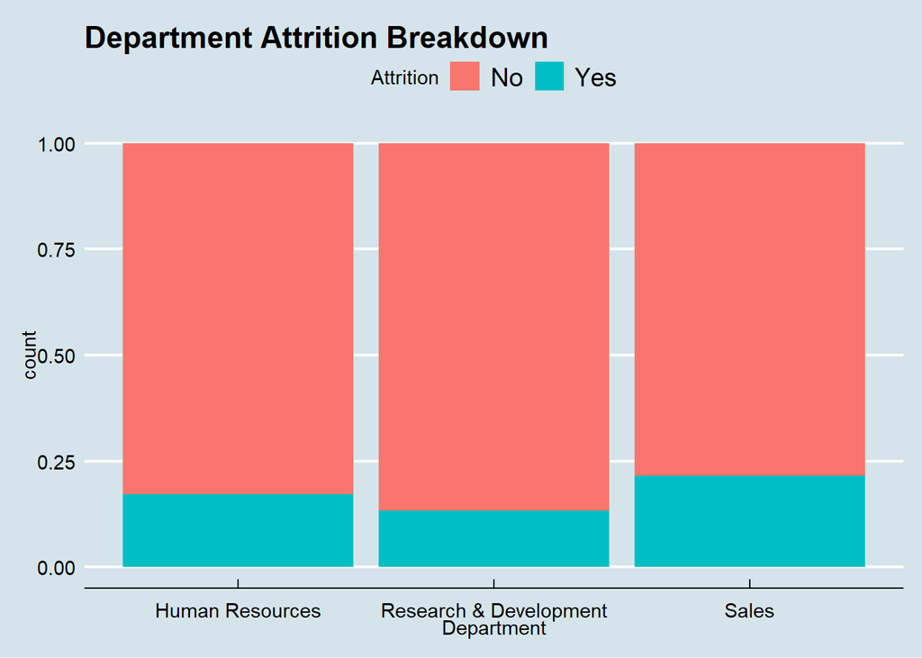

```r
ggplot(Case2, aes(x = Department, fill = Attrition)) + geom_bar(position = "fill") + ggtitle("Department Attrition Breakdown") + theme_economist()
```

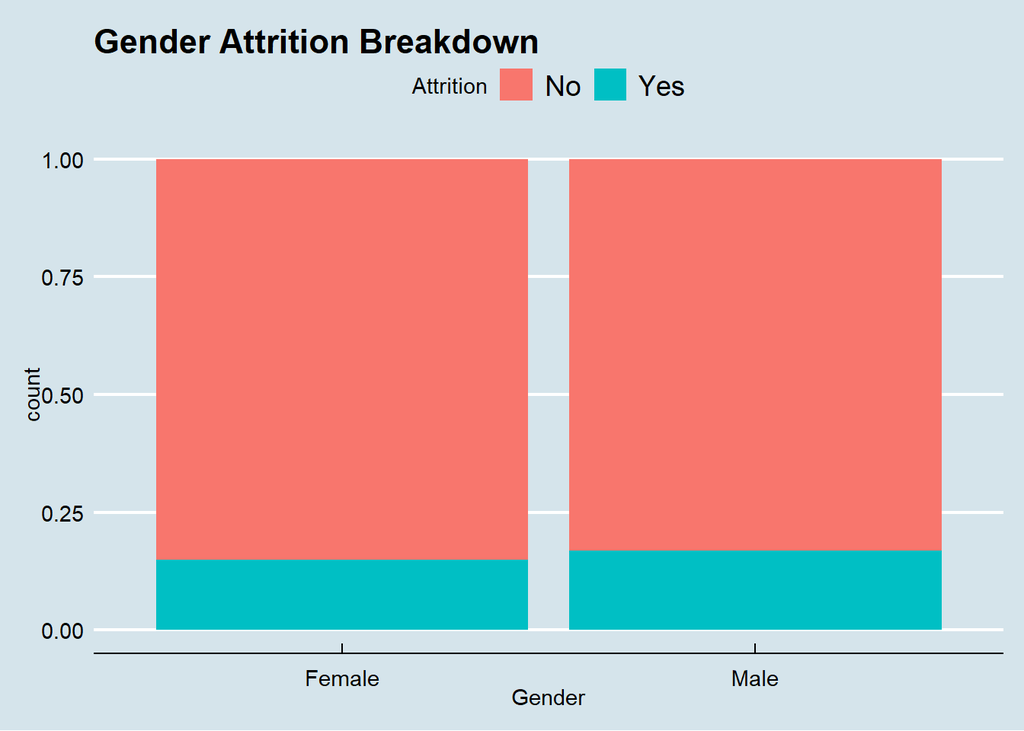

```r
ggplot(Case2, aes(x = Gender, fill = Attrition)) + geom_bar(position = "fill") + ggtitle("Gender Attrition Breakdown") + theme_economist()
```

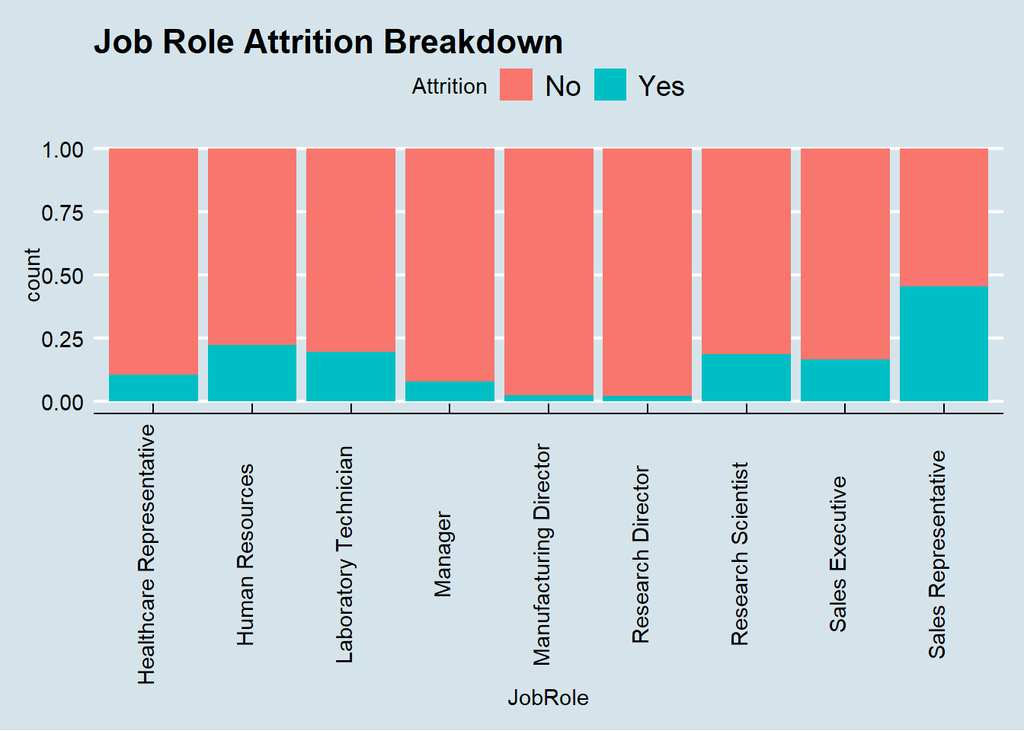

```r
ggplot(Case2, aes(x = JobRole, fill = Attrition)) + geom_bar(position = "fill") + ggtitle("Job Role Attrition Breakdown") + theme_economist() + theme(axis.text.x = element_text(angle = 90))
```

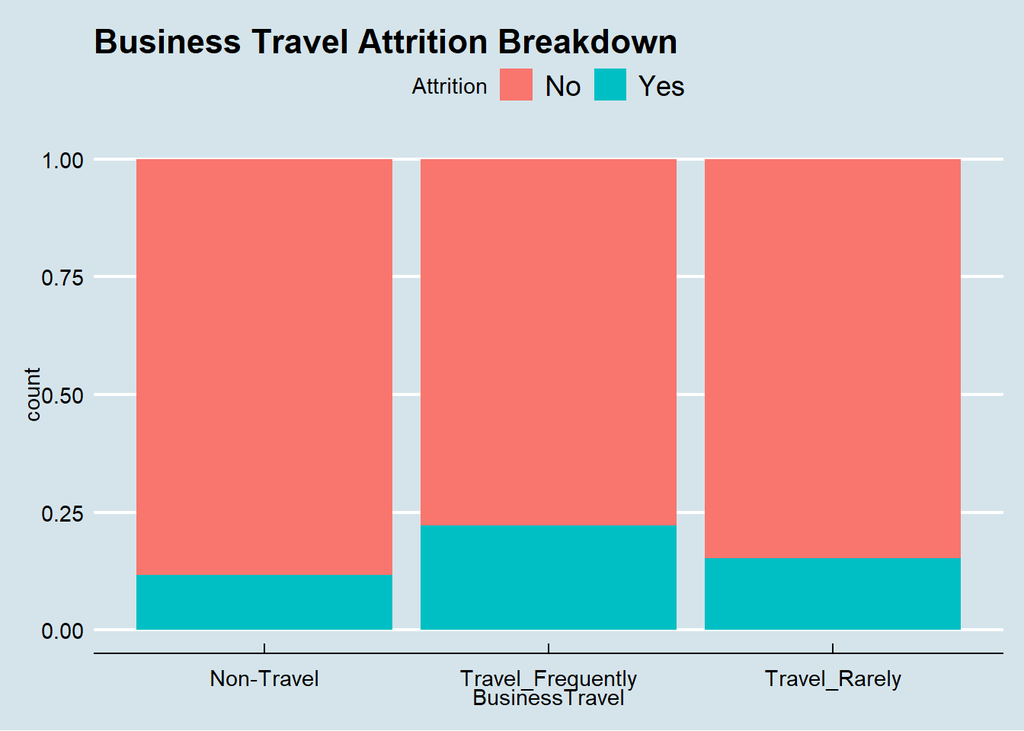

```r
ggplot(Case2, aes(x = BusinessTravel, fill = Attrition)) + geom_bar(position = "fill") + ggtitle("Business Travel Attrition Breakdown") + theme_economist()
```

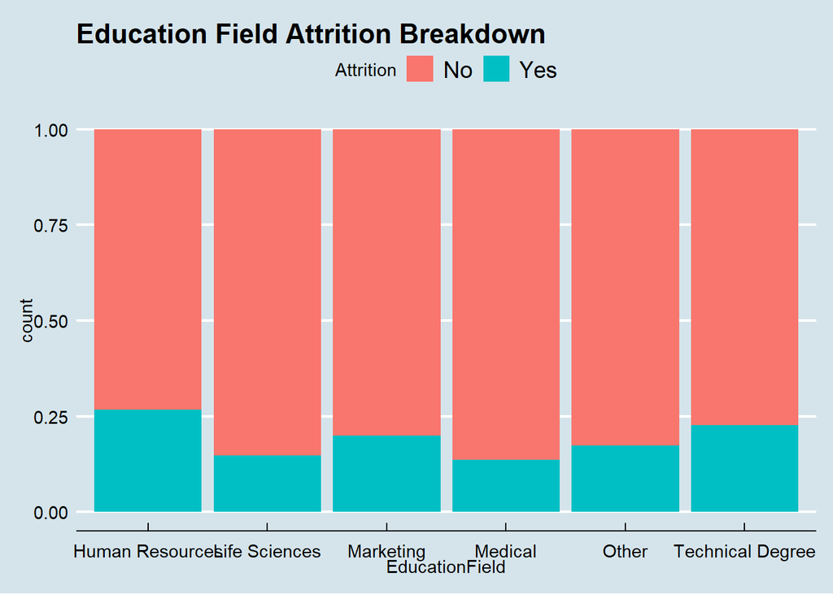

```r
ggplot(Case2, aes(x = EducationField, fill = Attrition)) + geom_bar(position = "fill") + ggtitle("Education Field Attrition Breakdown") + theme_economist()
```

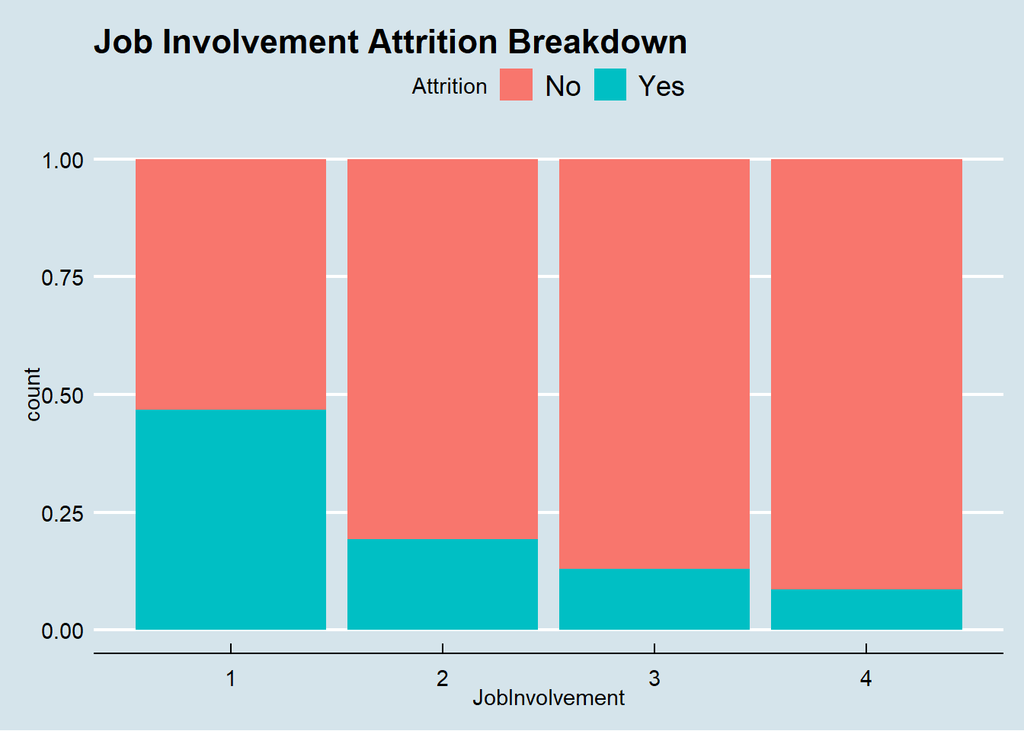

```r
ggplot(Case2, aes(x = JobInvolvement, fill = Attrition)) + geom_bar(position = "fill") + ggtitle("Job Involvement Attrition Breakdown") + theme_economist()
```

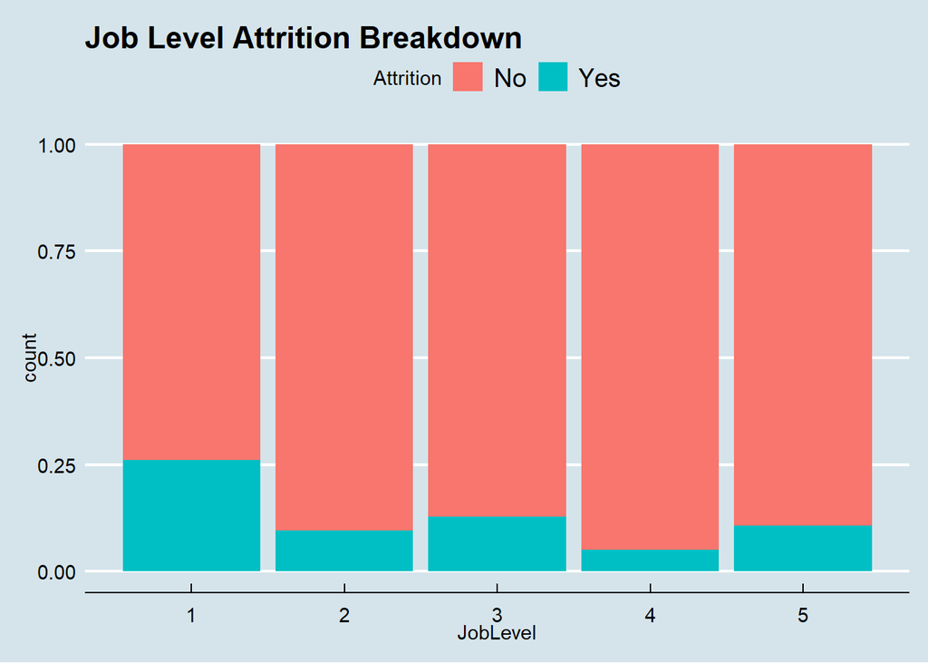

```r
ggplot(Case2, aes(x = JobLevel, fill = Attrition)) + geom_bar(position = "fill") + ggtitle("Job Level Attrition Breakdown") + theme_economist()
```

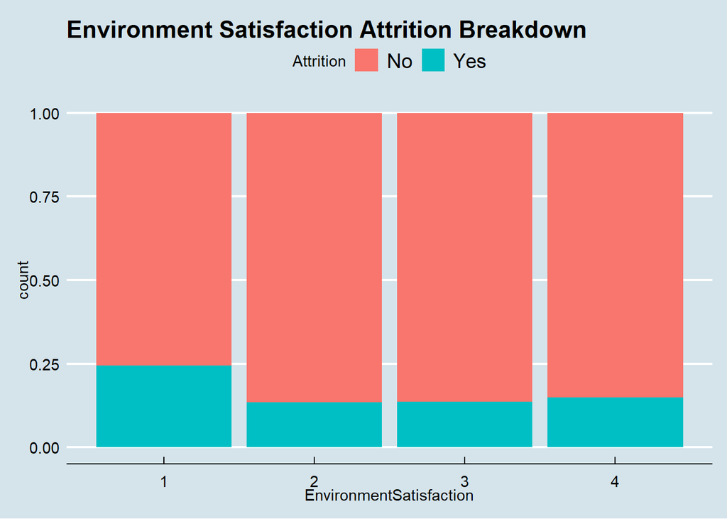

```r
ggplot(Case2, aes(x = EnvironmentSatisfaction, fill = Attrition)) + geom_bar(position = "fill") + ggtitle("Environment Satisfaction Attrition Breakdown") + theme_economist()
```

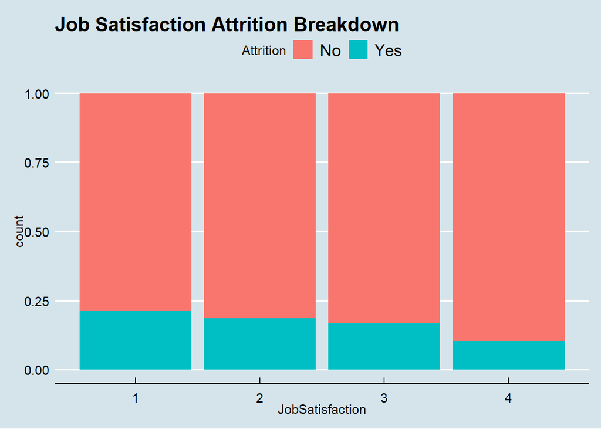

```r
ggplot(Case2, aes(x = JobSatisfaction, fill = Attrition)) + geom_bar(position = "fill") + ggtitle("Job Satisfaction Attrition Breakdown") + theme_economist()
```

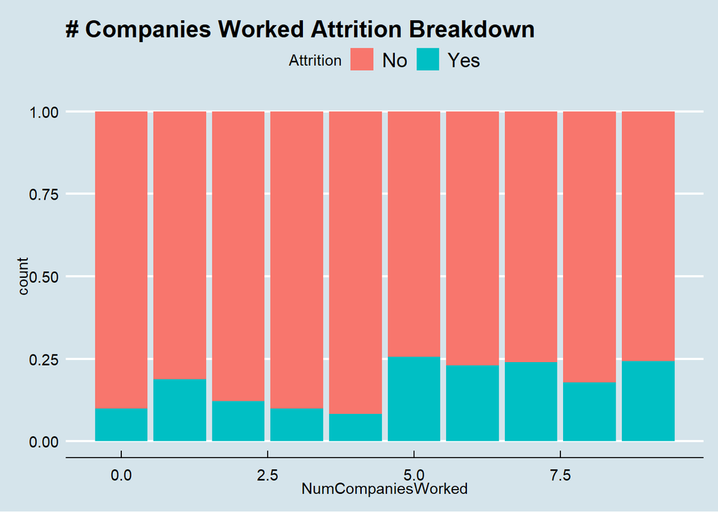

```r
ggplot(Case2, aes(x = NumCompaniesWorked, fill = Attrition)) + geom_bar(position = "fill") + ggtitle("# Companies Worked Attrition Breakdown") + theme_economist()
```

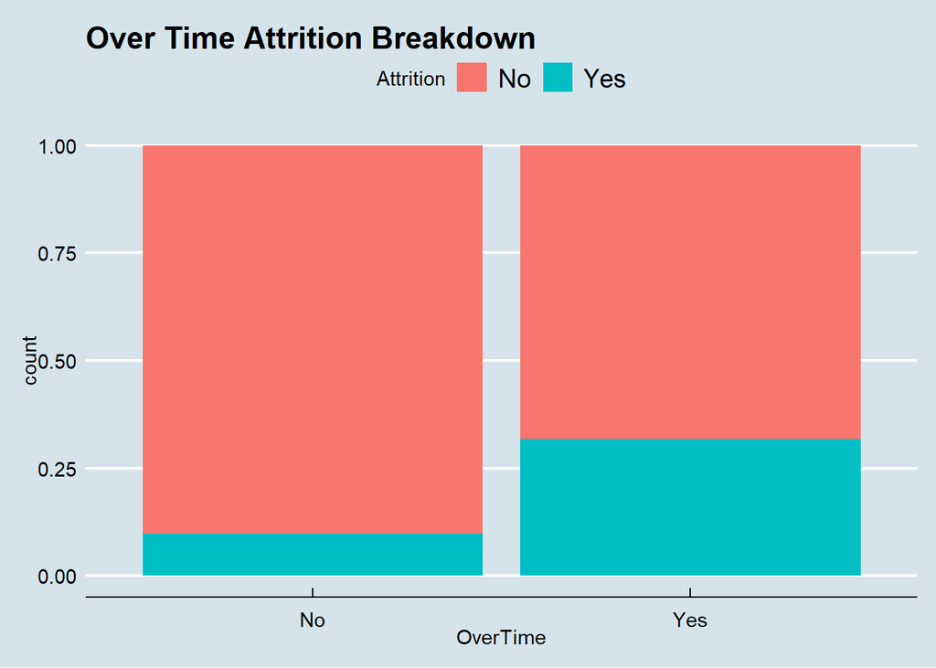

```r
ggplot(Case2, aes(x = OverTime, fill = Attrition)) + geom_bar(position = "fill") + ggtitle("Over Time Attrition Breakdown") + theme_economist()
```

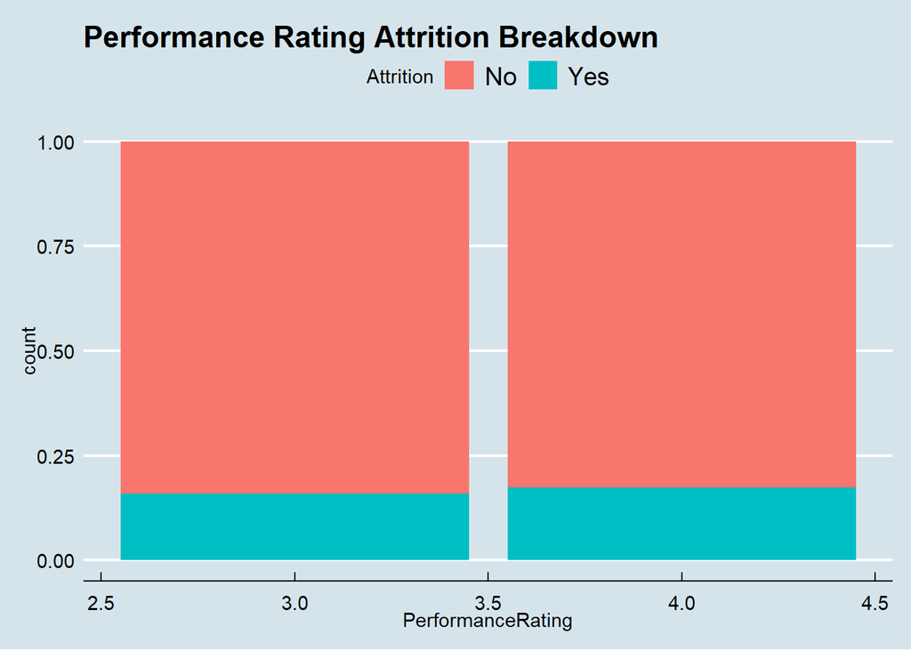

```r
ggplot(Case2, aes(x = PerformanceRating, fill = Attrition)) + geom_bar(position = "fill") + ggtitle("Performance Rating Attrition Breakdown") + theme_economist()
```

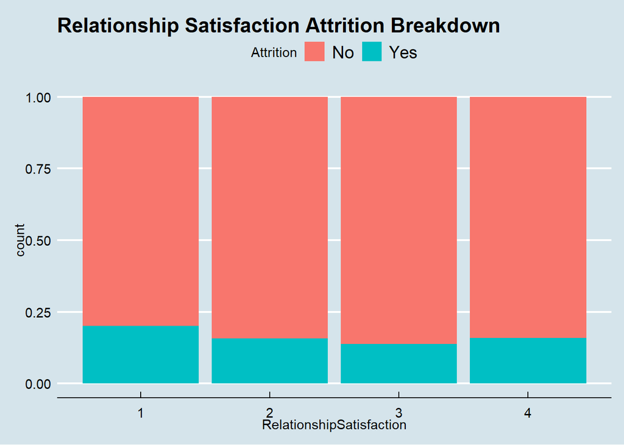

```r
ggplot(Case2, aes(x = RelationshipSatisfaction, fill = Attrition)) + geom_bar(position = "fill") + ggtitle("Relationship Satisfaction Attrition Breakdown") + theme_economist()
```

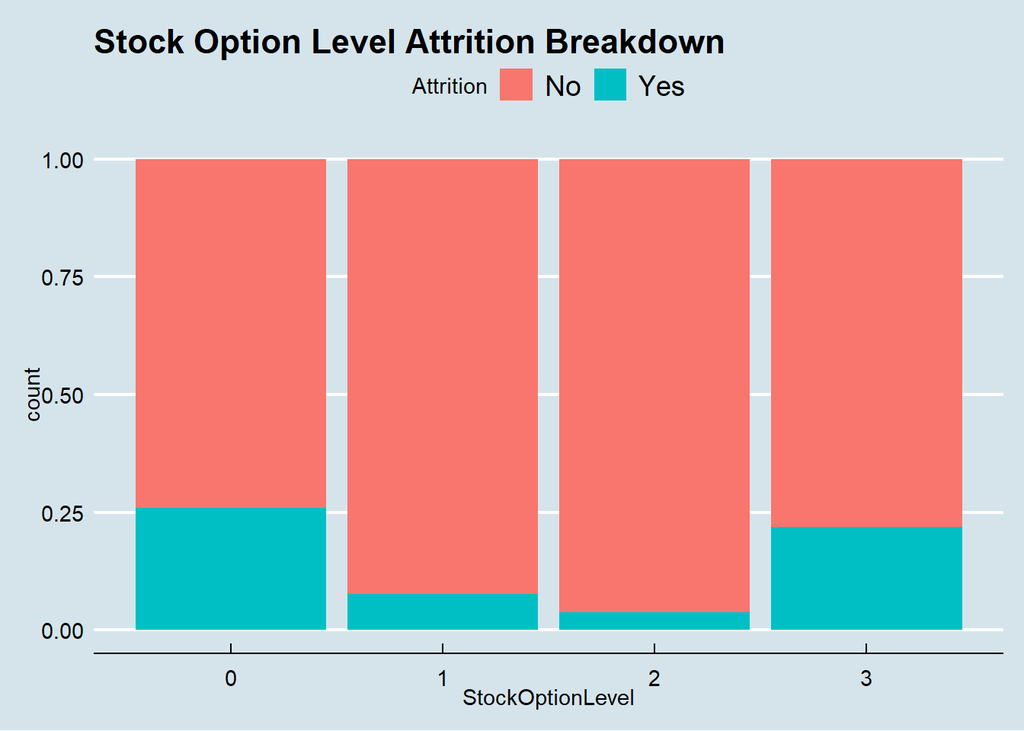

```r
ggplot(Case2, aes(x = StockOptionLevel, fill = Attrition)) + geom_bar(position = "fill") + ggtitle("Stock Option Level Attrition Breakdown") + theme_economist()
```

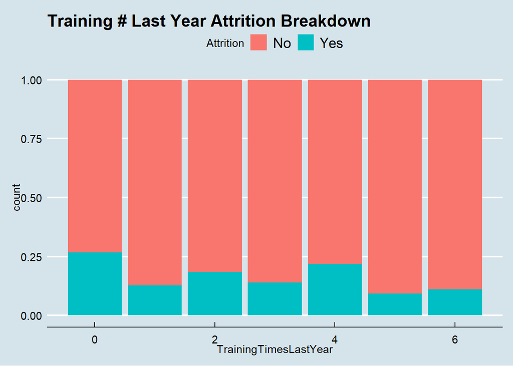

```r
ggplot(Case2, aes(x = TrainingTimesLastYear, fill = Attrition)) + geom_bar(position = "fill") + ggtitle("Training # Last Year Attrition Breakdown") + theme_economist()
```

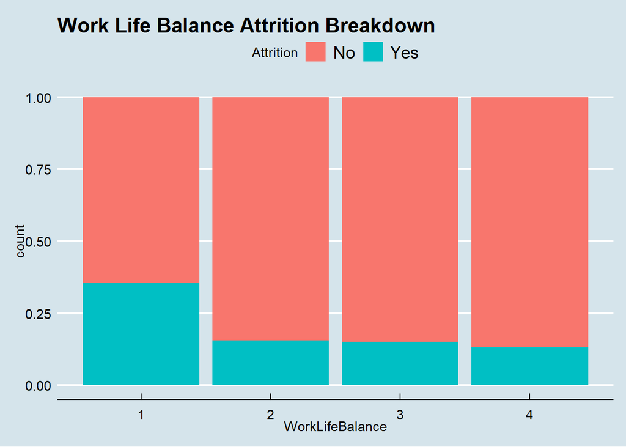

```r
ggplot(Case2, aes(x = WorkLifeBalance, fill = Attrition)) + geom_bar(position = "fill") + ggtitle("Work Life Balance Attrition Breakdown") + theme_economist()
```

```r
library(tidyverse)
df1 = Case2 %>% select(Attrition, JobRole)
df2 = as.data.frame(apply(table(df1), 2, function(x) x/sum(x)))
df2$Attrition = rownames(df2)
print(df2)
```

```
##     Healthcare Representative Human Resources Laboratory Technician    Manager
## No                  0.8947368       0.7777778             0.8039216 0.92156863
## Yes                 0.1052632       0.2222222             0.1960784 0.07843137
##     Manufacturing Director Research Director Research Scientist Sales Executive
## No              0.97701149        0.98039216          0.8139535           0.835
## Yes             0.02298851        0.01960784          0.1860465           0.165
##     Sales Representative Attrition
## No             0.5471698        No
## Yes            0.4528302       Yes
```

```r
df1 = Case2 %>% select(Attrition, JobInvolvement)
df2 = as.data.frame(apply(table(df1), 2, function(x) x/sum(x)))
df2$Attrition = rownames(df2)
print(df2)
```

```
##             1         2         3          4 Attrition
## No  0.5319149 0.8070175 0.8696498 0.91358025        No
## Yes 0.4680851 0.1929825 0.1303502 0.08641975       Yes
```

```r
df1 = Case2 %>% select(Attrition, WorkLifeBalance)
df2 = as.data.frame(apply(table(df1), 2, function(x) x/sum(x)))
df2$Attrition = rownames(df2)
print(df2)
```

```
##             1       2         3         4 Attrition
## No  0.6458333 0.84375 0.8496241 0.8673469        No
## Yes 0.3541667 0.15625 0.1503759 0.1326531       Yes
```

```r
df1 = Case2 %>% select(Attrition, JobSatisfaction)
df2 = as.data.frame(apply(table(df1), 2, function(x) x/sum(x)))
df2$Attrition = rownames(df2)
print(df2)
```

```
##             1        2         3        4 Attrition
## No  0.7877095 0.813253 0.8307087 0.896679        No
## Yes 0.2122905 0.186747 0.1692913 0.103321       Yes
```

### Next look at boxplots in order to assess distribution of continuous variables relative to Attrition

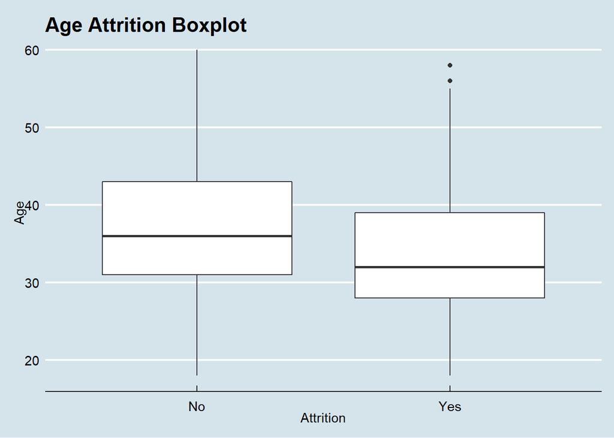

```r
ggplot(data=Case2, mapping = aes(x = Attrition, y = Age)) + geom_boxplot() + ggtitle("Age Attrition Boxplot") + theme_economist()
```

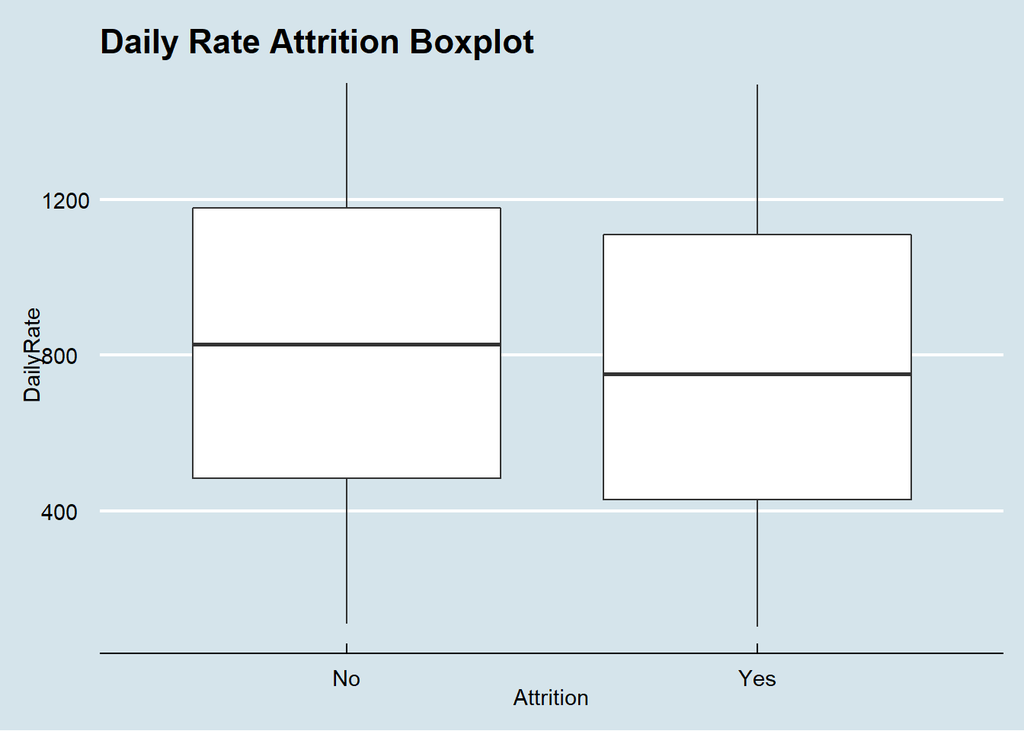

```r
ggplot(data=Case2, mapping = aes(x = Attrition, y = DailyRate)) + geom_boxplot() + ggtitle("Daily Rate Attrition Boxplot") + theme_economist()
```

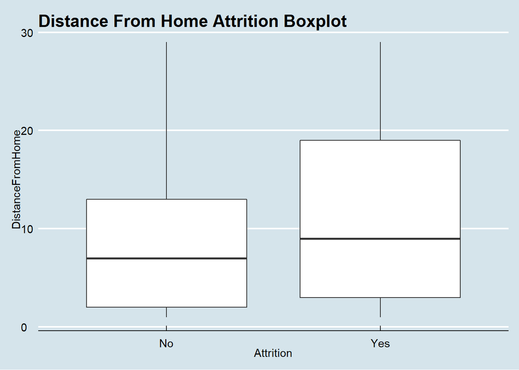

```r
ggplot(data=Case2, mapping = aes(x = Attrition, y = DistanceFromHome)) + geom_boxplot() + ggtitle("Distance From Home Attrition Boxplot") + theme_economist()
```

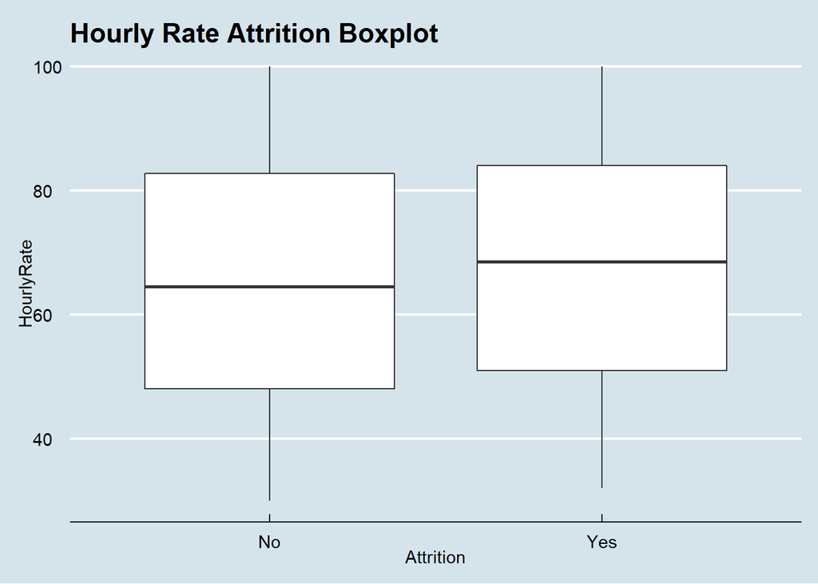

```r
ggplot(data=Case2, mapping = aes(x = Attrition, y = HourlyRate)) + geom_boxplot() + ggtitle("Hourly Rate Attrition Boxplot") + theme_economist()
```

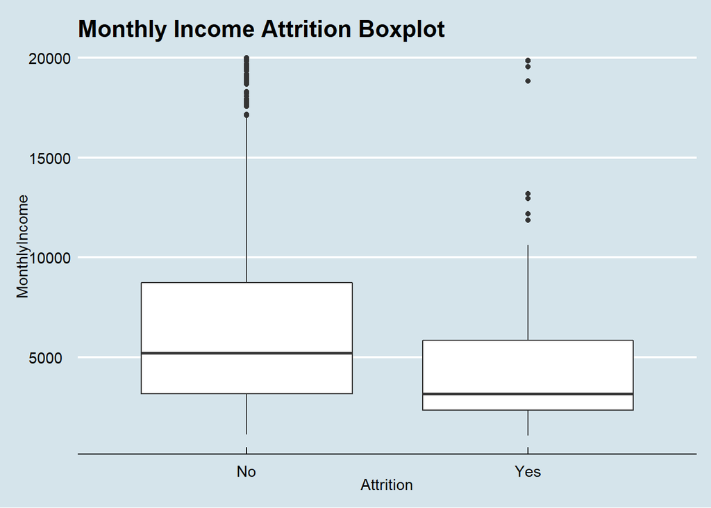

```r
ggplot(data=Case2, mapping = aes(x = Attrition, y = MonthlyIncome)) + geom_boxplot() + ggtitle("Monthly Income Attrition Boxplot") + theme_economist()
```

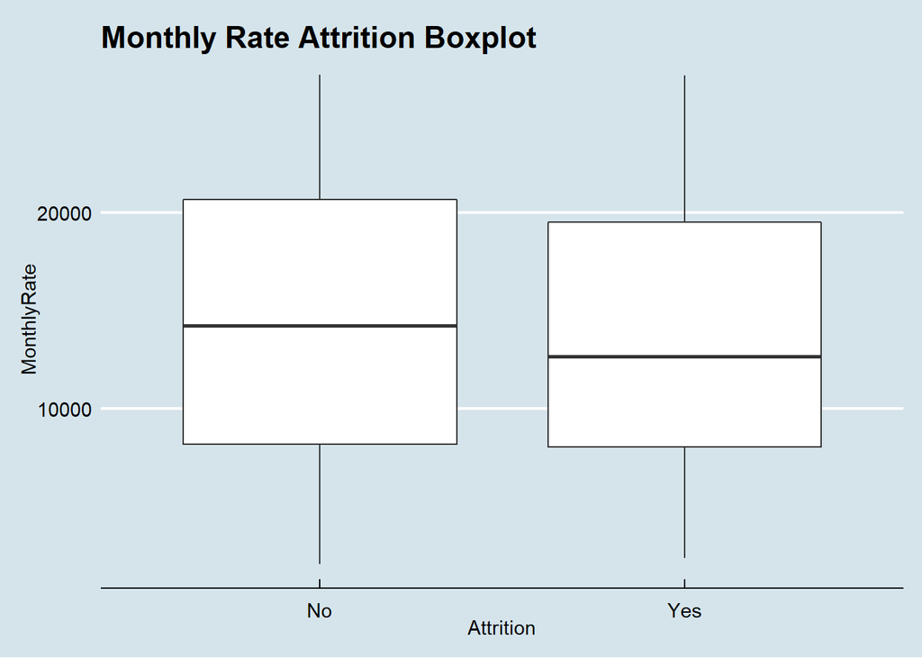

```r
ggplot(data=Case2, mapping = aes(x = Attrition, y = MonthlyRate)) + geom_boxplot() + ggtitle("Monthly Rate Attrition Boxplot") + theme_economist()
```

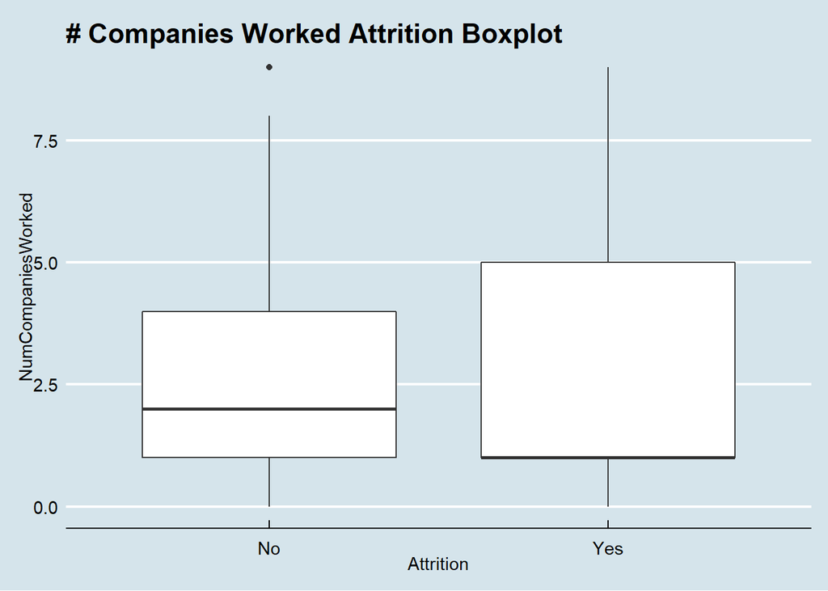

```r
ggplot(data=Case2, mapping = aes(x = Attrition, y = NumCompaniesWorked)) + geom_boxplot() + ggtitle("# Companies Worked Attrition Boxplot") + theme_economist()
```

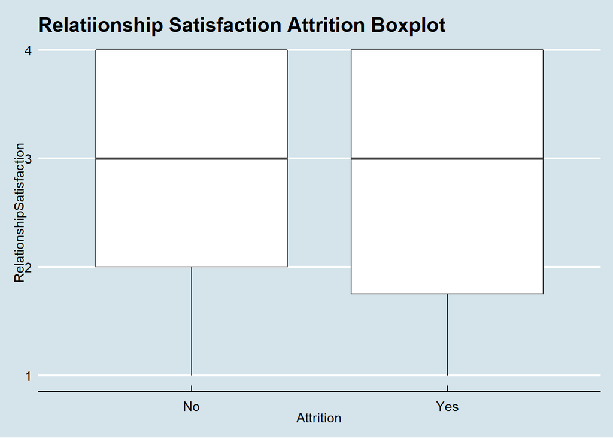

```r
ggplot(data=Case2, mapping = aes(x = Attrition, y = RelationshipSatisfaction)) + geom_boxplot() + ggtitle("Relatiionship Satisfaction Attrition Boxplot") + theme_economist()
```

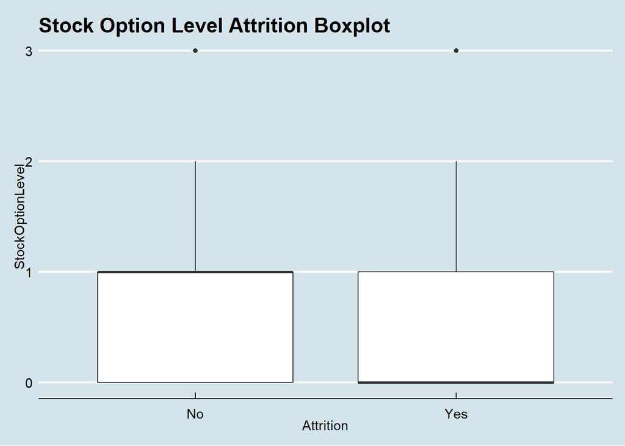

```r
ggplot(data=Case2, mapping = aes(x = Attrition, y = StockOptionLevel)) + geom_boxplot() + ggtitle("Stock Option Level Attrition Boxplot") + theme_economist()
```

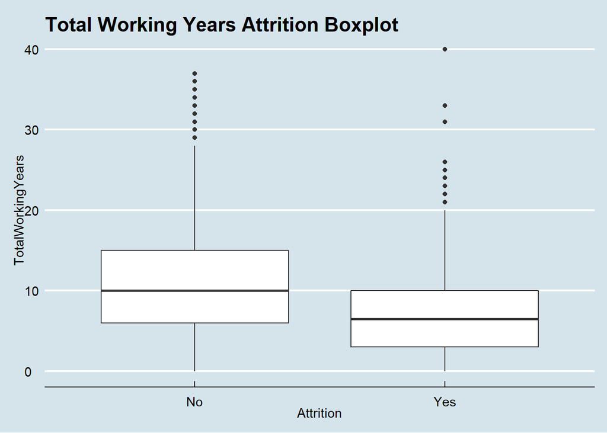

```r
ggplot(data=Case2, mapping = aes(x = Attrition, y = TotalWorkingYears)) + geom_boxplot()+ ggtitle("Total Working Years Attrition Boxplot") + theme_economist()
```

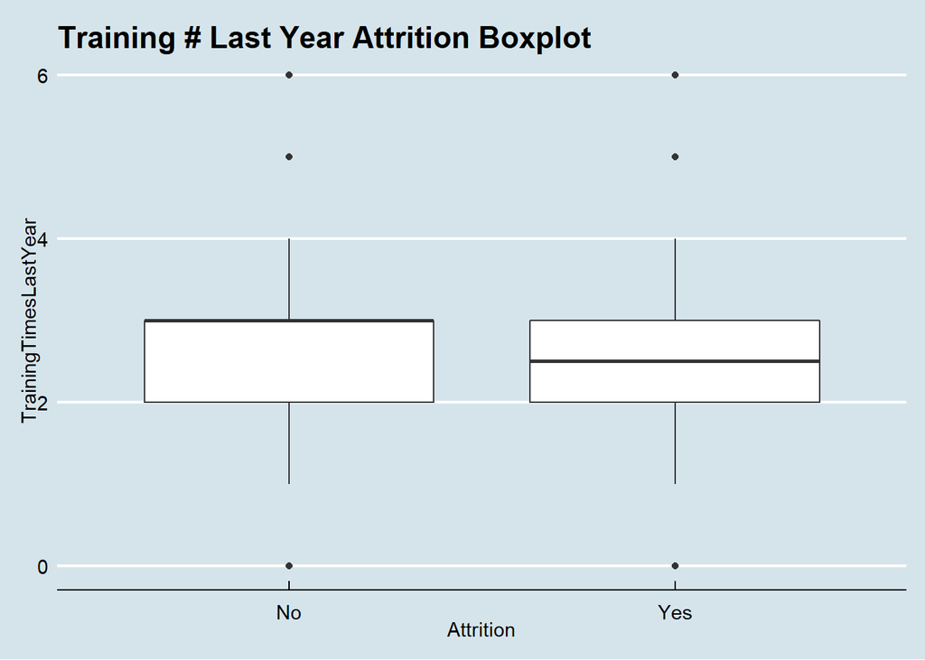

```r
ggplot(data=Case2, mapping = aes(x = Attrition, y = TrainingTimesLastYear)) + geom_boxplot() + ggtitle("Training # Last Year Attrition Boxplot") + theme_economist()
```

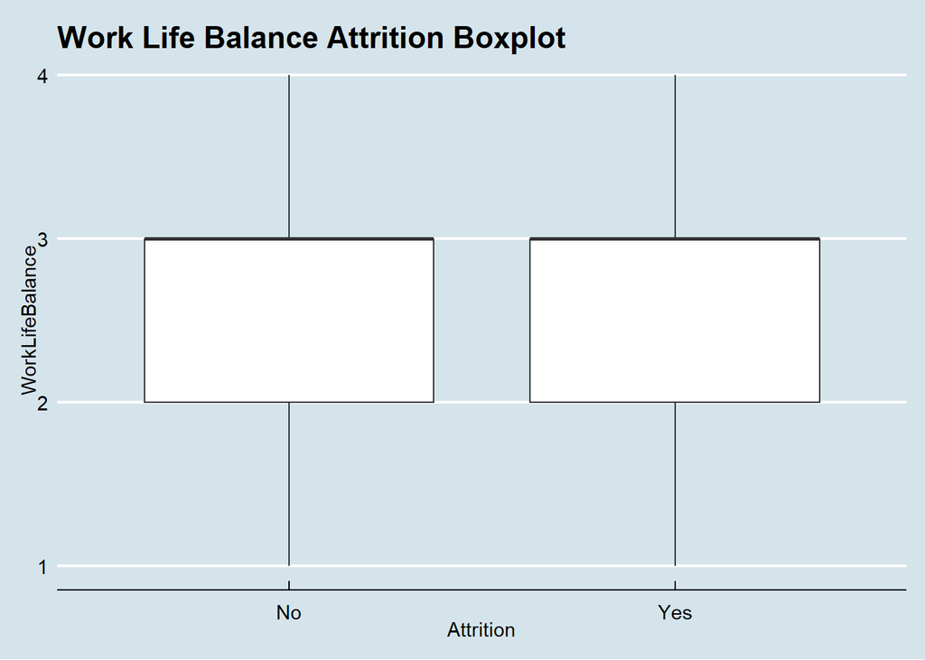

```r
ggplot(data=Case2, mapping = aes(x = Attrition, y = WorkLifeBalance)) + geom_boxplot() + ggtitle("Work Life Balance Attrition Boxplot") + theme_economist()
```